# Análise das estatística do time mandante

## posse de bola

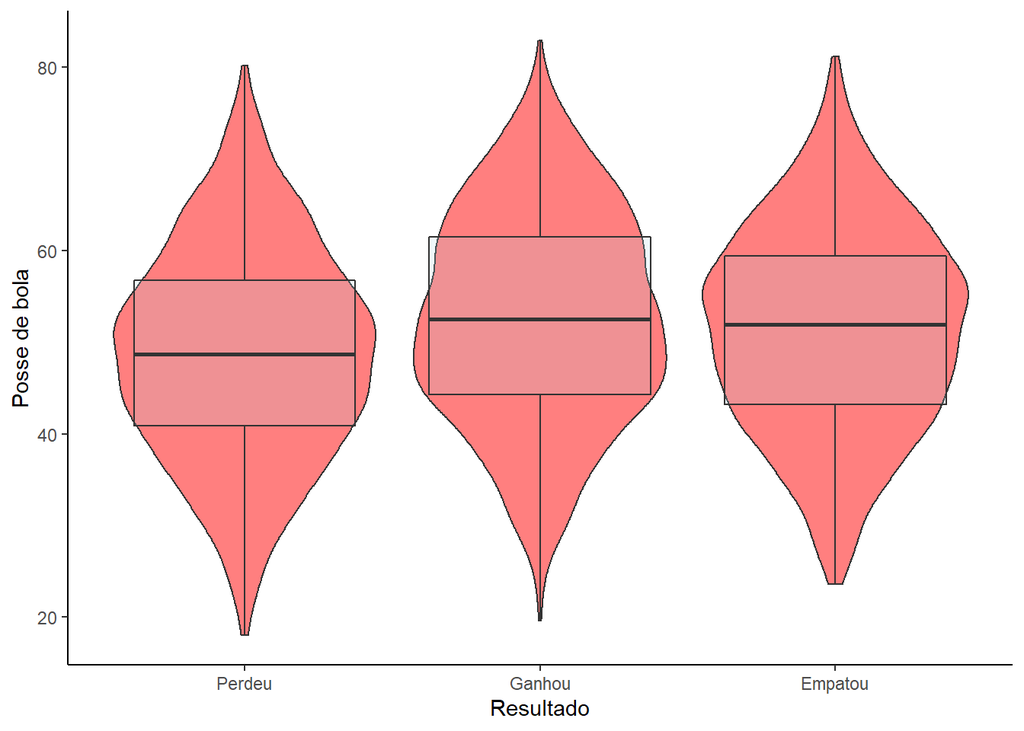

Posse de bola do mandante vencedor aparenta ser um pouco maior que os demais resultados

## Escanteios

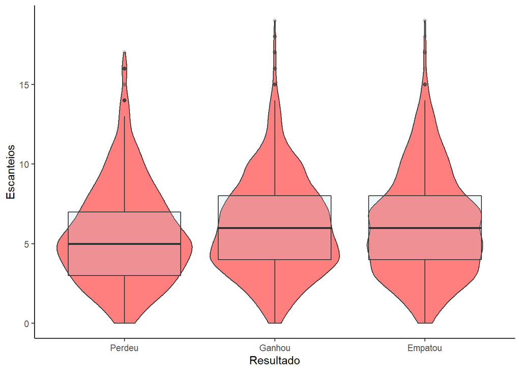

Quando o mandante perde os escanteios aparentam ocorrer em menor número

## Chutões

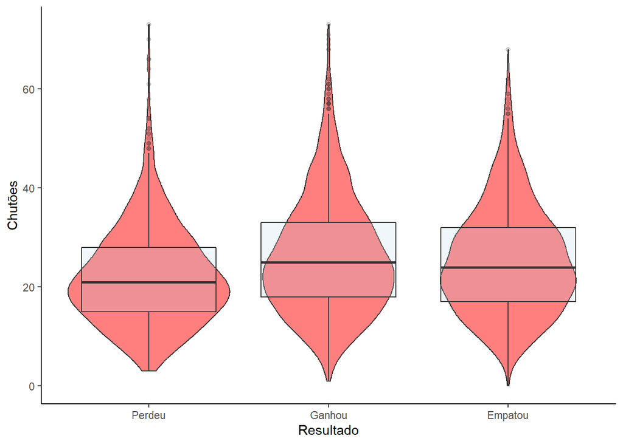

Aparenta haver uma pequena diferença, quando observamos as medianas, entre osresultados, onde os mandantes que perderam tendem a dar menos chutões do que os que venceram ou empataram

## Faltas cometidas

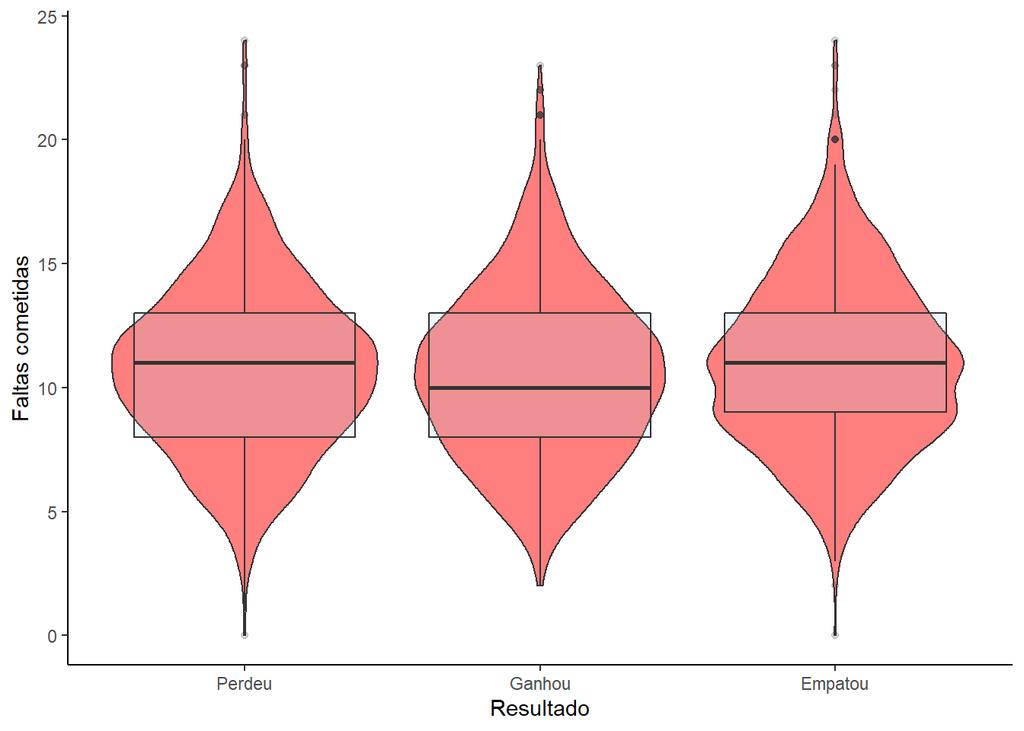

Times mandantes que ganharam parecem possui uma quantidade de faltas cometidas um pouco menos que os demais resultados

## Impedimentos

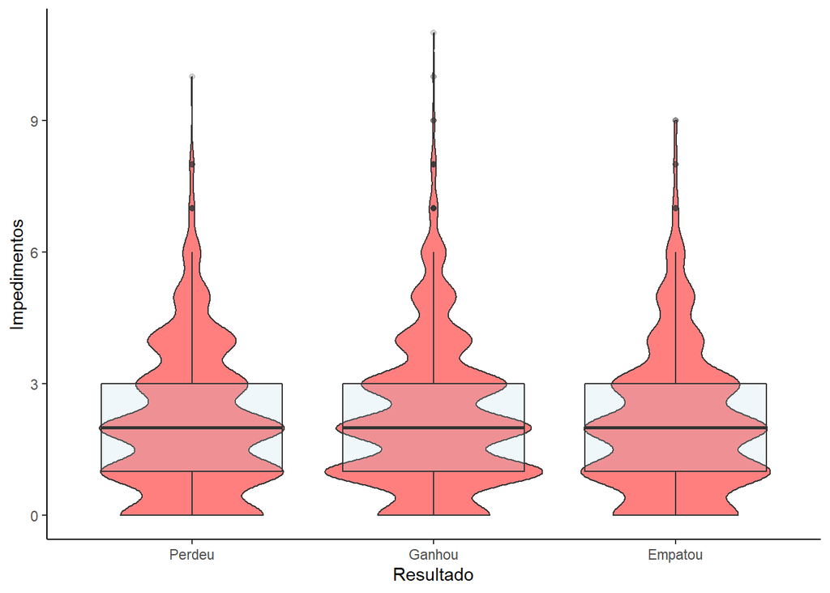

Nenhuma diferença pode ser percebida na quantidade de impedimentos

## Passes

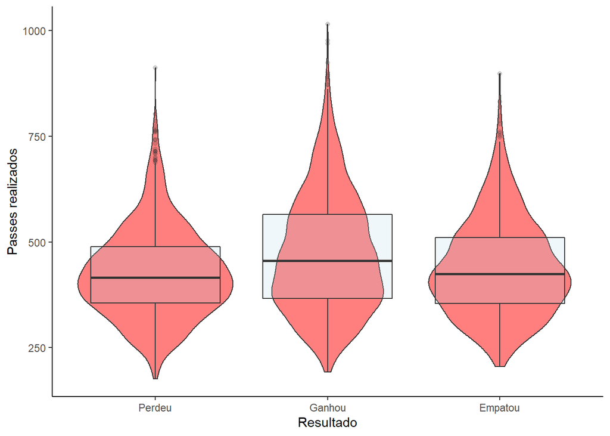

Times mandantes que ganharam parecem possuir mais passes realizados durante a partida

## Cartões amarelos

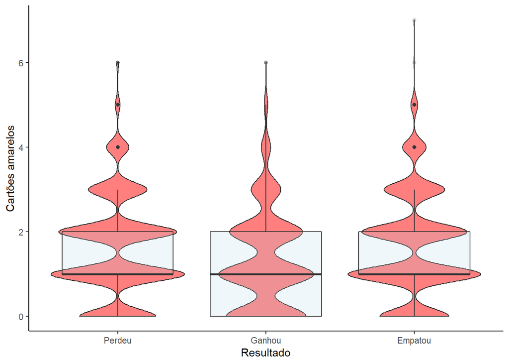

Comportamento semelhante entre os resultados, não parece interferir na vitória

## Cartões vermelho

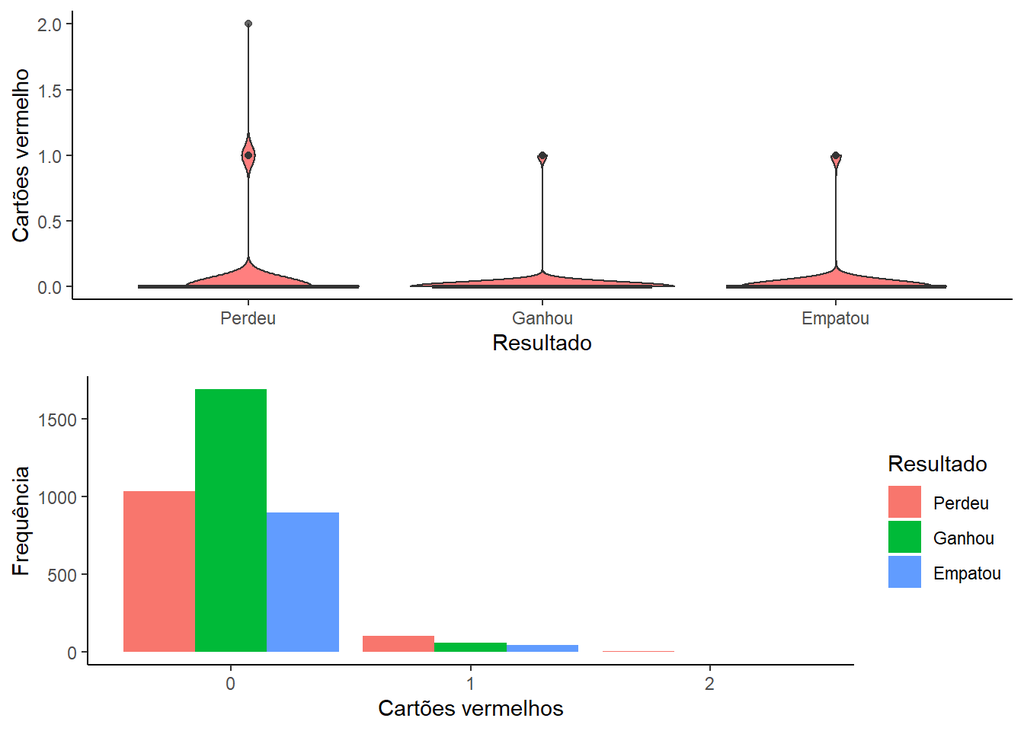

Quando há ocorrência de 2 cartões vermelho, o time mandante tende a perder

## Chutes

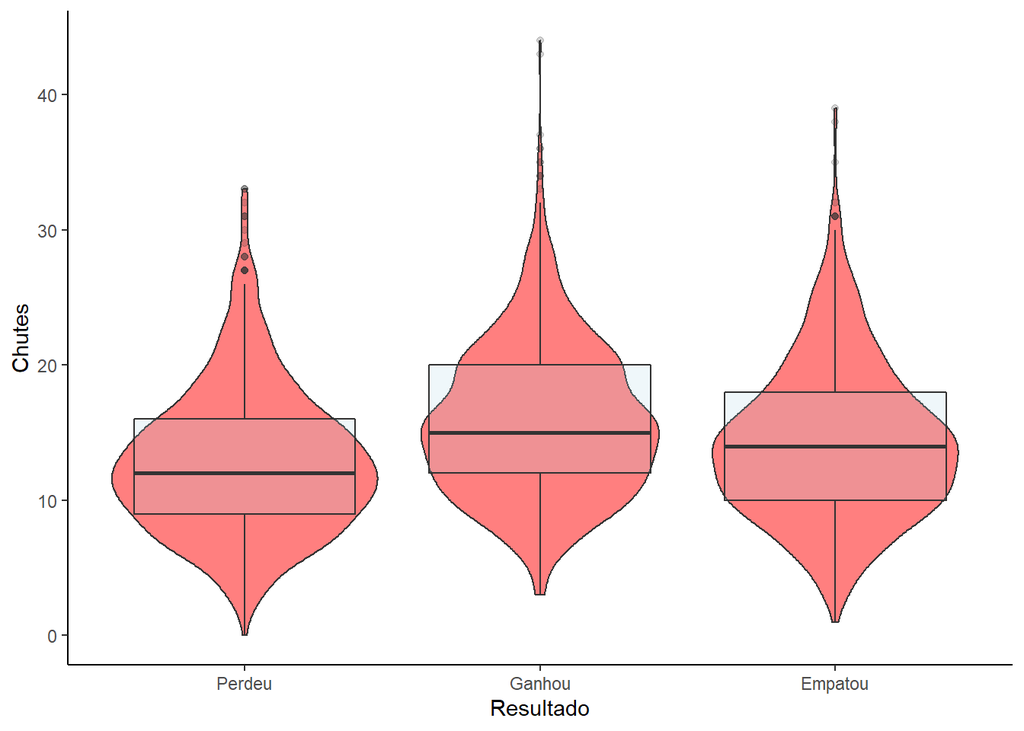

Times que venceram aprentar dar mais chutes

## Chutes no gol

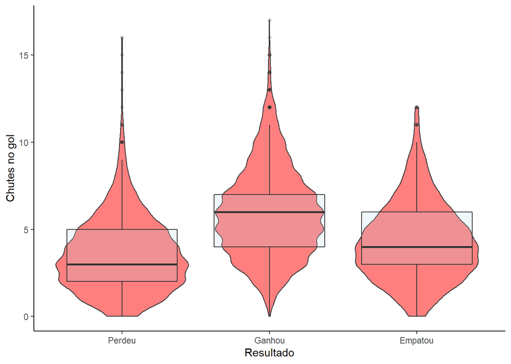

Dar mais chutes no gol aparenta influenciar na vitória

## Roubadas de bola

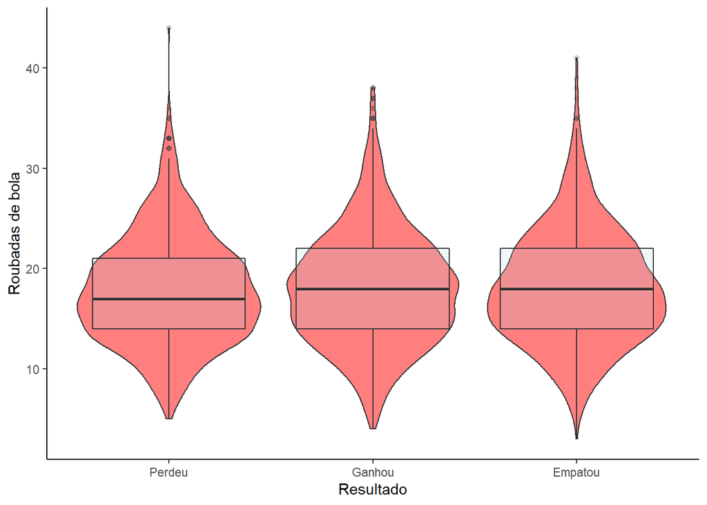

A quantidade de roubadas de bola não aparenta influenciar no resultado

## Toques na bola

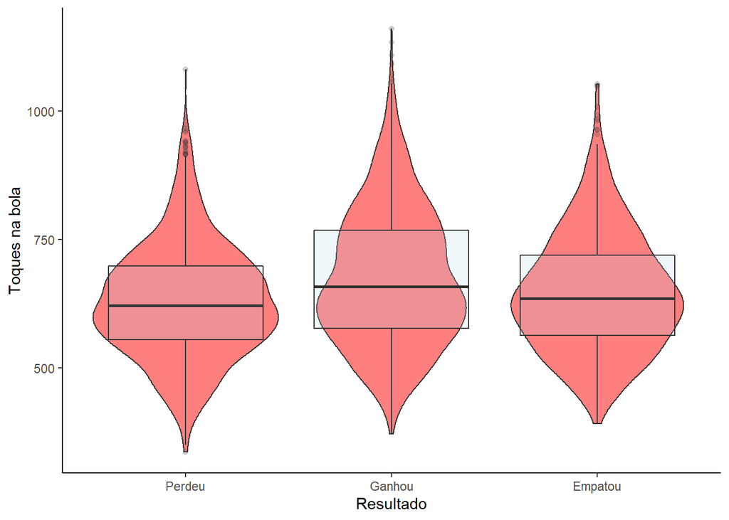

Times que venceram tendem a possuir maior quantidade de toques na bola durante a partida